# A3: Incarceration

Shipei Huang

08/04/23

### Introduction

The U.S. has the most people in jail worldwide, and Black Americans, due to historical and current racism, are locked up much more than others. In this report, I chose the last data set (a smaller dataset about prison/jail population per 100,000 people (rate) per county/state starting at 1990 in Washington) given in our homework instruction. The reason I chose this dataset is because I live in WA state and would like to know more about the incarceration in our state.

### Summary Information

```r
average_pop
```

```
## # A tibble: 29 × 2
##     year avg_jail_pop
##    <int>        <dbl>
##  1  1990      125719.
##  2  1991      128862.
##  3  1992      132327.
##  4  1993      135355.
##  5  1994      137825.
##  6  1995      140539.
##  7  1996      142814.
##  8  1997      145506.
##  9  1998      147938.
## 10  1999      149809.
## # ℹ 19 more rows
```

```r
average_jail_pop_rate_1990
```

```
##   mean(total_jail_pop_rate, na.rm = TRUE)
## 1                                221.0728
```

```r
average_jail_pop_rate_2018
```

```
##   mean(total_jail_pop_rate, na.rm = TRUE)
## 1                                326.6744
```

```r
median_jail_pop_rate
```

```
##      X  fips year state    county_name urbanicity total_pop total_jail_pop_rate
## 1 1062 53073 2007    WA Whatcom County  small/mid    192837              277.89
##   female_jail_pop_rate male_jail_pop_rate aapi_jail_pop_rate
## 1                88.41             547.15               86.4
##   black_jail_pop_rate latinx_jail_pop_rate native_jail_pop_rate
## 1             1790.28                401.7              2035.35
##   white_jail_pop_rate total_prison_pop_rate female_prison_pop_rate
## 1              250.72                313.04                  60.41
##   male_prison_pop_rate aapi_prison_pop_rate black_prison_pop_rate
## 1               567.96                    0                2813.3
##   latinx_prison_pop_rate native_prison_pop_rate white_prison_pop_rate
## 1                 493.52                 1258.7                243.78
```

```r
highest_jail_pop_rate
```

```
##      X  fips year state   county_name urbanicity total_pop total_jail_pop_rate
## 1 1122 53077 2009    WA Yakima County  small/mid    239604              992.82
##   female_jail_pop_rate male_jail_pop_rate aapi_jail_pop_rate
## 1               201.29            1467.41            1840.04
##   black_jail_pop_rate latinx_jail_pop_rate native_jail_pop_rate
## 1            12188.62                709.8              2674.84
##   white_jail_pop_rate total_prison_pop_rate female_prison_pop_rate
## 1              529.17                 499.8                  98.64
##   male_prison_pop_rate aapi_prison_pop_rate black_prison_pop_rate
## 1               891.43                    0               2493.61
##   latinx_prison_pop_rate native_prison_pop_rate white_prison_pop_rate
## 1                 384.22                  971.8                517.01
```

```r
average_black_rate
```

```
##   mean(black_jail_pop_rate, na.rm = TRUE)
## 1                                 1868.63
```

```r
average_white_rate
```

```
##   mean(white_jail_pop_rate, na.rm = TRUE)
## 1                                261.5801
```

### The Dataset

1. Who collected the data? This dataset was assembled using information collected by the U.S. Department of Justice Bureau of Justice Statistics (BJS), supplemented with data from state departments of correction when federal data is not available
2. How was the data collected or generated? The prison variables draw on the National Corrections Reporting Program (NCRP) and data collected directly from state departments of correction, when NCRP data is not available or is unreliable. These two sources are combined when creating the prison variables. The jails data draws on the Annual Survey of Jails (ASJ), Census of Jails (COJ), and population and admissions variables from Death in Custody Reporting Program (DCRP). The ASJ and COJ data are combined when creating the jail variables. This dataset provides county-level data on prison and jail incarceration and related measures over time for the entire United States.
3. Why was the data collected?  
   The purpose of this dataset is to provide detail on the sources and variables in the Incarceration Trends dataset.This dataset is a good reference for important topics like racial and money-related differences, decisions made by the government, and fairness problems in the system.
4. How many observations (rows) are in your data?  
   1131 rows
5. How many features (columns) are in the data?  
   23columns
6. What, if any, ethical questions or questions of power do you need to consider when working with this data?  
   I think we need to consider the fairness and bias problem that may exist when working with this data. If the data is not objective and itself has bias. Then our trending analysis would be biased as well. I would also consider the transparency of this data when working with it. For example, I will consider that is the data collection process transparent, and can others understand how the data was gathered? Is there a risk of hidden agendas or manipulation.
7. What are possible limitations or problems with this data? Using this data the wrong way could accidentally support wrong ideas or keep unfair things going. The data comes mostly from the government or big organizations, which might make it not completely fair because they collect and understand it differently. Also, sometimes the data from these places might not be accurate because they want to look good or follow certain rules.

### Trends Over Time Chart

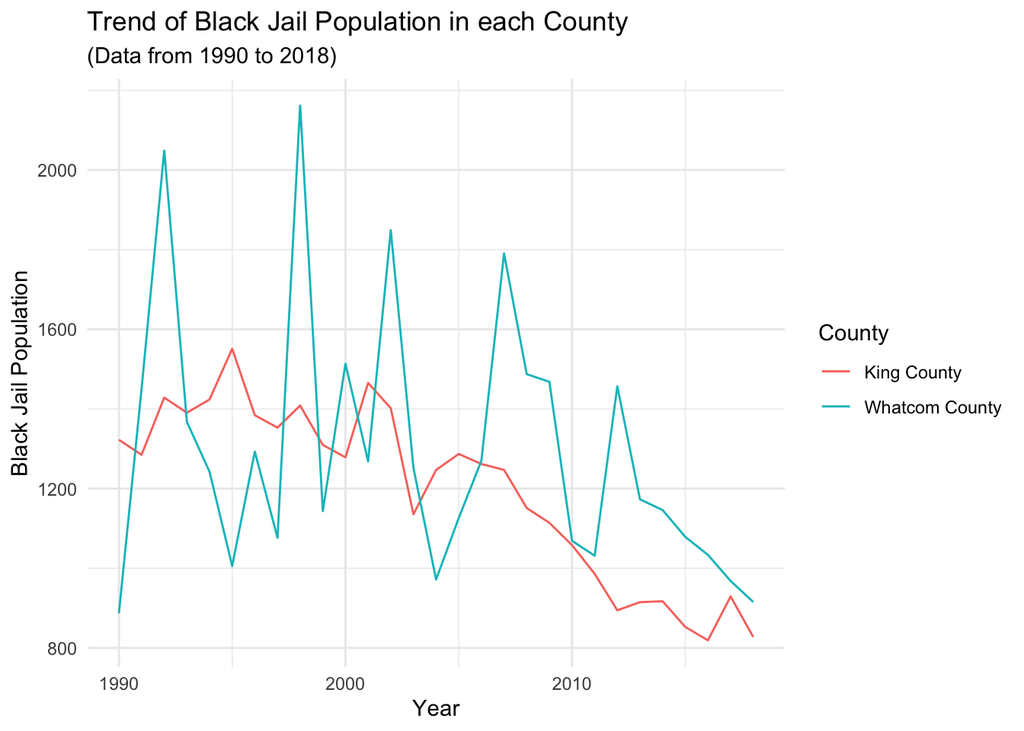

```r
chart1
```

I chose King County because we live here and I chose Whatcom county because it’s the median observation among all the WA counties. As we can see from the graph, King County had a lower average black jail population from 1990 to 2018. It also had smaller fluctuations in jail population change from year to year in overall. Since Whatcom county was the median observation in our data set (based on the median_jail_pop_rate), we can believe that King county is a relatively safe place than most of the WA Counties.

### Variable Comparison Chart

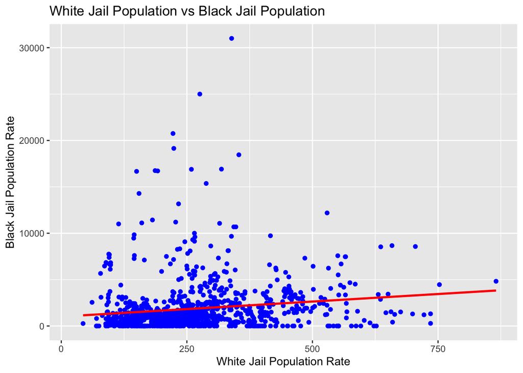

This graph shows the weak relationship between average jail population rate of the black and white people. We can still see that the black people have higher average jail population rate than white people. Based on the graph above, there is a very weak relationship between white jail population and black jail population. The distribution of the points is so random and the slope of the regression line is small.

Based on the regression line, we can predict that as white jail population rate increases, the black jail population rate also increases. This totally make sense especially when there is high unemployment.

### Map

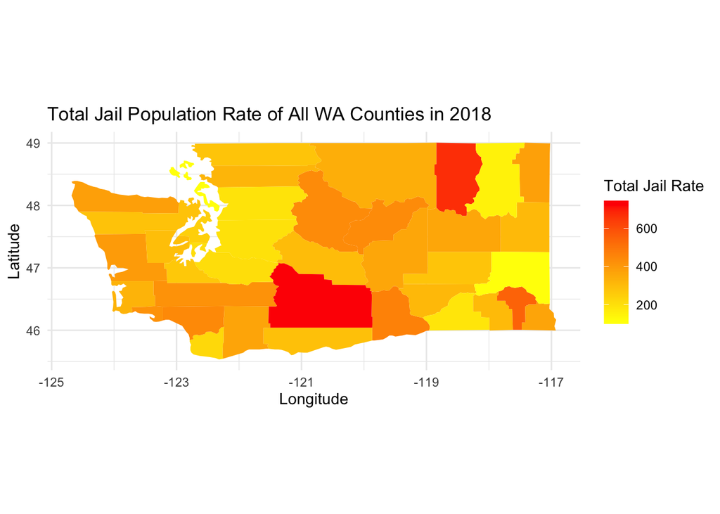

```r
chart3
```